# nf20917_EMATM0061_B

Pantelis Zoumpoulidis

05/01/2021

## Section C: Supervised Learning

# Task 1.

Supervised learning is the task of learning a function that outputs a value based on input data that have feature vectors and labels. The method that we will use for this purpose is called k-nearest neighbors classification (k-NN). Classification is the categorize of a new observation depended on the observations we already have and the category that they belong to. K-nearest neighbor classification is a clever, yet simple to understand the algorithm. Firstly, we choose a number of “neighbors”. This refers to the number of the closest neighbors we want to count when a new observation is being calculated. The distance is being measured by the [Euclidean distance](https://en.wikipedia.org/wiki/Euclidean_distance). The Euclidean distance between 2 data points $P_1 (x_1, y_1)$ and $P_2 (x_2, y_2)$ is $d = \sqrt{(x_2 - x_1) ^ 2 + (y_2 - y_1) ^ 2}$. Then, among these K-neighbors, we count the number of data points in each category. Finally, we assign the new observation to the category that we counted the most neighbors. This algorithm can be used for every classification problem, but its biggest disadvantage is that the bigger the dataset is, the slower it gets.

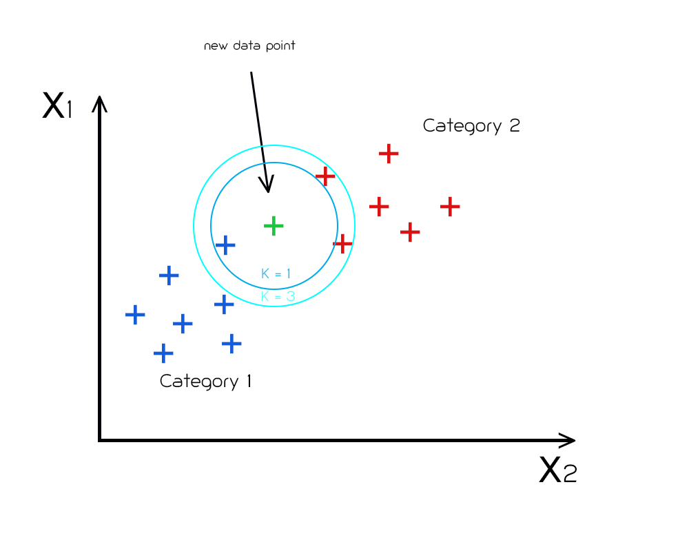

In the graph above, we can see an example of how the K-neighbors classification algorithm works. When K = 1, the new data point will classify as Category 1, because the closest neighbor to it is from Category 1. On the other hand, when K = 3, the new data point will classify as Category 2, because there are more neighbors from Category 2 than from Category 1 in the first 3 neighbors. The next graph demonstrates how the Euclidean distance is being computed.

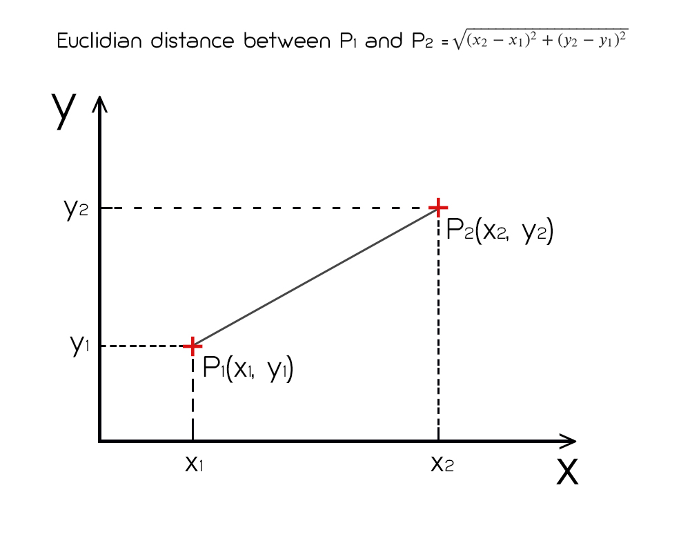

# Task 2.

```r
  originalData <- read.csv("/Users/zoumpp/Documents/Data Science MSc/Statistical Computing and Empirical Methods (SCEM) TB1/Assesment/Section C Supervised Learning/heart.csv", header = TRUE)   # importing the dataset. header = TRUE because the first row is consisted of the names of the columns
```

For the purposes of this assessment, we are going to use the [Heart Disease UCI dataset](https://www.kaggle.com/ronitf/heart-disease-uci) downloaded from [kaggle](https://www.kaggle.com/). This database consists of 14 different attributes of real patients that had a diagnosis (negative or positive) for the presence or absence of heart disease. The original database contained 76 attributes, while this is a “processed” database with only 14 of them. We will use the absence or the presence of heart disease as our classification problem and 13 different features for this project. The following are the variables that we are going to use for our classification problem:

1. target (absence or presence of heart disease): binary variable (0 or 1)
2. age: discrete variable (integer from 29 to 77)
3. sex: binary variable (0 or 1)
4. chest pain type (values: 0, 1, 2, 3): discrete variable (integer from 0 to 3)
5. resting blood pressure: discrete variable (integer from 94 to 200)
6. serum cholestorol in mg/dl: discrete variable (integer from 126 to 564)
7. fasting blood sugar > 120 mg/dl: binary variable (0 or 1)
8. resting electrocardiographic results (values: 0, 1, 2): discrete variable (integer from 0 to 2)
9. maximum heart rate achieved: discrete variable (integer from 71 to 202)
10. exercise-induced angina: binary variable (0 or 1)
11. oldpeak = ST depression induced by exercise relative to rest: continuous variable (real from 0 to 6.2)
12. the slope of the peak exercise ST segment: discrete variable (integer from 0 to 2)
13. number of major vessels (values: 0, 1, 2, 3) colored by flouroscopy: discrete variable (integer from 0 to 3)
14. thal (normal, fixed defect or reversible defect): discrete variable (integer from 1 to 3)

For reasons of confidentiality, the names and the social security numbers of the patients were removed from the “processed” database. To begin with, we are going to import our dataset and clear any observations that are not in compliance with the information of the attributes (eg. if there is a number different than 0, 1, 2, or 3 in the number of major vessels colored by flouroscopy variable).

```r
  library(tidyverse) # import library

  data <- originalData %>% # from original data
    filter(cp %in% (0:3) & restecg %in% (0:2) & ca %in% (0:3) & thal %in% (1:3)) %>% # filter with the information of the attributes
    select(target, age, cp, sex, trestbps, chol, fbs, restecg, thalach, exang, oldpeak, slope, ca, thal) %>% # select columns
    na.omit() # drop na rows
```

So, after the data wrangling and cleaning, we have a total of 296 observations consisted of 14 columns.

# Task 3.

First things first, because of the different ranges of the values of the variables, we need to normalize our data before we use them for any kind of data processing and analysis. The reason behind this is that in order to have an efficient model we can’t have big differences between the values of the variables because all the variables have the same weight over the outcome. After the normalization, all variables will consist of a real number ranging from 0 to 1 except the binary ones that will be either 0 or 1.

```r
  normalize <- function(x) { return((x - min(x)) / (max(x) - min(x))) } # normalization function

  data $ age <- normalize(data $ age) # normalize age
  data $ cp <- normalize(data $ cp) # normalize cp
  data $ trestbps <- normalize(data $ trestbps) # normalize trestbps
  data $ chol <-normalize(data $ chol) # normalize chol
  data $ restecg <- normalize(data $ restecg) # normalize restecg
  data $ thalach <- normalize(data $ thalach) # normalize thalach
  data $ oldpeak <- normalize(data $ oldpeak) # normalize oldpeak
  data $ slope <- normalize(data $ slope) # normalize slope
  data $ ca <- normalize(data $ ca) # normalize ca
  data $ thal <- normalize(data $ thal) # normalize thal
```

The following is a preview of our dataset after all the modifications made.

```r
  data %>% head(3) # display the 3 first rows of data
```

```
##   target       age        cp sex  trestbps      chol fbs restecg   thalach
## 1      1 0.7083333 1.0000000   1 0.4811321 0.2442922   1     0.0 0.6030534
## 2      1 0.1666667 0.6666667   1 0.3396226 0.2831050   0     0.5 0.8854962
## 3      1 0.2500000 0.3333333   0 0.3396226 0.1780822   0     0.0 0.7709924
##   exang   oldpeak slope ca thal
## 1     0 0.3709677     0  0  0.0
## 2     0 0.5645161     0  0  0.5
## 3     0 0.2258065     1  0  0.5
```

The appropriate metric for the performance of our model is the percentage of false predictions. The lowest the percentage, the better the performance. In this Task, we will explore the performance of our model on both train and validation data as we vary the amount of train data used. The number of K-neighbors that we are going to use for our model, equals 17 as it is the number closest to the root of the total of our observations ($\sqrt{296} =$ 17.2046505 $\approx 17$).

```r
  library(class) # import library

  computeFalsePredictionsPercentageKNN <- function(trainX, trainY, testX, testY, k) { # compute the false predictions percentage of what is entered as test data based on what is entered as train data

    set.seed(11012021) # set random seed for reproducibility

    predictions = knn(train = trainX,
                   test = testX,
                   cl = trainY,
                   k = k) # train our model and predict based on train data

    numberOfFalsePredictions <- sum((predictions != testY), na.rm = TRUE) # number of false predictions

    totalPredictions <- length(predictions) # number of total predictions

    falsePredictionsPercentage <- mean((numberOfFalsePredictions / totalPredictions) * 100) # false predictions percentage

    return(falsePredictionsPercentage) # return false predictions percentage

  }

  getRandomTrainDataWithTheSameValidationData <- function(data, trainingDataPercentage, y) { # get random train and validation data based on the percentage of data given

    totalNumber <- data %>% nrow() # number of total observations

    trainNumber <- floor(totalNumber * (trainingDataPercentage / 100)) # number of train examples (data percentage used - 20% (validation data))
    validationNumber <- floor(totalNumber * 0.2) # number of validate samples (20% of data)

    # randomly sample indices for the test, validation and train data

    set.seed(11012021) # set random seed for reproducibility
    validationIndicies <- sample(seq(totalNumber), validationNumber) # random sample of test indicies, GETTING THE SAME 20% OF THE DATASET EVERY TIME
    trainIndicies <- sample(setdiff(seq(totalNumber), validationIndicies), trainNumber) # validate data indicies

    # extract train, validation and test data sets based on their indices

    train <- data %>% filter(row_number() %in% trainIndicies) # train data
    validation <- data %>% filter(row_number() %in% validationIndicies) # validation data

    # split the train, validation and test data sets into feature vectors and labels

    trainX <- train %>% select(-y) # train feature vectors
    trainY <- train %>% select(y) # train labels

    validationX <- validation %>% select(-y) # validate feature vectors
    validationY <- validation %>% select(y) # validate labels

    return(list(trX = trainX, trY = trainY, vX = validationX, vY = validationY)) # return the data

  }

  trainAndValidationFalsePredictionsPercentageForDifferentNumberOfTrainData <- function(data, trainingDataPercentage, y, k) { # compute the false predictions percentage on train and validation data

    randomTrainAndValidationData <- getRandomTrainDataWithTheSameValidationData(data, trainingDataPercentage, y) # get random train data with the same validation data every time

    trainX <- randomTrainAndValidationData[[1]] # train features
    trainY <- unlist(randomTrainAndValidationData[[2]], use.names = FALSE) # train labels
    validationX <- randomTrainAndValidationData[[3]] # validation features
    validationY <- unlist(randomTrainAndValidationData[[4]], use.names = FALSE) # validation labels

    trainFalsePredictionsPercentage<- computeFalsePredictionsPercentageKNN(trainX, trainY, trainX, trainY, k) # compute the false predictions percentage on the train data

    validationFalsePredictionsPercentage <- computeFalsePredictionsPercentageKNN(trainX, trainY, validationX, validationY, k) # compute the false predictions percentage on the validation data

    return(list(tFPP = trainFalsePredictionsPercentage, vFPP = validationFalsePredictionsPercentage)) # return the false predictions percentage

  }

  trainDataPercentages <- seq(20, 100 - 20 - 20, 1) # from 20% to 60%. The rest are 20% validation data and 20% test data (not used)

  k <- 17 # number of k is set to 17. it is the closest root to our total number of observations

  trainAndValidationFalsePredictionsPercentagewithDifferentNumberofTrainDataUsed <- data.frame(trainDataPercentage = trainDataPercentages) %>% # create adata frame with all the train data percentages used and the train and validation false prediction percentages
    mutate(trainFalsePredictionsPercentage = map(trainDataPercentage, ~trainAndValidationFalsePredictionsPercentageForDifferentNumberOfTrainData(data, .x, "target", k)[1] %>% unlist())) %>% # compute the train false predictions percentage for the different number of train data used
    mutate(validationFalsePredictionsPercentage = map(trainDataPercentage, ~trainAndValidationFalsePredictionsPercentageForDifferentNumberOfTrainData(data, .x, "target", k)[2] %>% unlist())) # compute the validation false predictions percentage for the different number of train data used

    ggPlotTrainData <- trainAndValidationFalsePredictionsPercentagewithDifferentNumberofTrainDataUsed %>% ggplot(aes(x = trainDataPercentage, y = as.numeric(trainFalsePredictionsPercentage))) + # create a ggplot
      geom_smooth(method = lm) + theme_bw() + # add smoother line and black and white background
      labs(x = "Train Data Percentage (%)", y = "Train False Prediction Percentage (%)") # set label names

      ggPlotValidationData <- trainAndValidationFalsePredictionsPercentagewithDifferentNumberofTrainDataUsed %>% ggplot(aes(x = trainDataPercentage, y = as.numeric(validationFalsePredictionsPercentage))) + # create a ggplot
      geom_smooth(method = lm) + theme_bw() + # add smoother line and black and white background
      labs(x = "Train Data Percentage (%)", y = "Validation False Prediction Percentage (%)") # set label names

      library(gridExtra) # import library
```

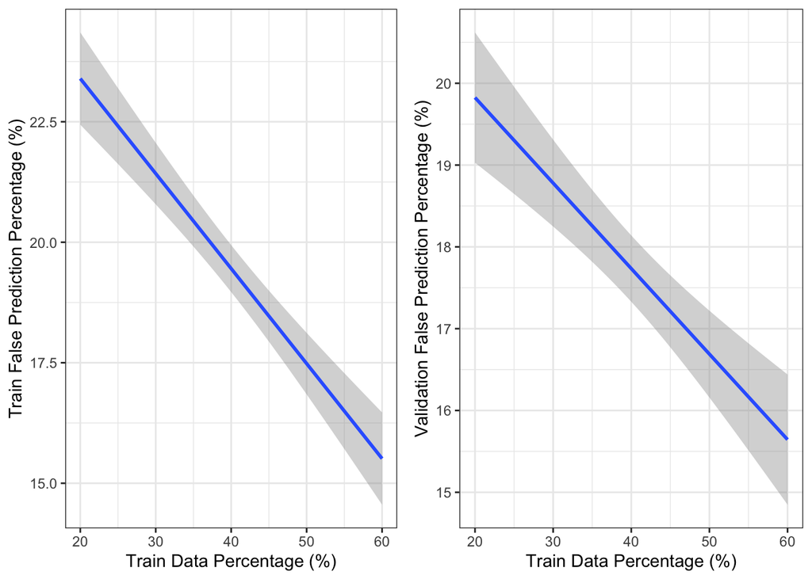

```r
  grid.arrange(ggPlotTrainData, ggPlotValidationData, ncol = 2) # display the plots
```

Above we can observe the percentage of false predictions changing, as the percentage of the train data used for the predictions change We detect a constant decrease in the percentage of the false predictions on both train and validation data as the number of data used is increasing (from 20% to 60%, 20% of them are the validation data) which is exactly what we were expecting. We observe a decent average false prediction percentage of 19.45% on train data which is higher, as we were expecting, than the 17.73% on validation data. Both of these percentages are not the most anticipated though.

# Task 4.

Additionally, we are going to explore the performance of our model as we vary our hyperparameter, which in our case is the number of K-neighbors. For this purpose, we are going to train our model and predict outcomes for 50 different neighbors (1 to 50), with the same train and validation data (80% of the whole dataset). Finally, we will demonstrate a plot of how the false prediction percentage is changing as the number of K-neighbors are changing.

```r
  getRandomTrainValidationAndTestData <- function(data, trainDataPercentage, validationDataPercentage, yName) { # get random train and validation data based on the percentage of data given

    # set the size of the train, validate and  test data sets

    totalNumber <- data %>% nrow() # total number of examples
    trainNumber <- floor(totalNumber * trainDataPercentage) # number of train examples
    vaidationNumber <- floor(totalNumber * validationDataPercentage) # number of validate samples
    testNumber <- totalNumber - (trainNumber + vaidationNumber) # number of test samples

    # randomly sample indices for the test, validation and train data

    set.seed(11012021) # set random seed for reproducibility
    testIndicies <- sample(seq(totalNumber), testNumber) # random sample of test indicies
    validationIndicies <- sample(setdiff(seq(totalNumber), testIndicies), vaidationNumber) # validate data indicies
    trainIndicies <- setdiff(seq(totalNumber), union(testIndicies, validationIndicies)) # training data indicies

    # extract train, validation and test data sets based on their indices

    trainData <- data %>% filter(row_number() %in% trainIndicies) # train data
    validationData <- data %>% filter(row_number() %in% validationIndicies) # validation data
    testData <- data %>% filter(row_number() %in% testIndicies) # test data

    # split the train, validation and test data sets into feature vectors and labels

    trainX <- trainData %>% select(-yName) # train feature vectors
    trainY <- trainData %>% pull(yName) # train labels

    validationX <- validationData %>% select(-yName) # validate feature vectors
    validationY <- validationData %>% pull(yName) # validate labels

    testX <- testData %>% select(-yName) # test feature vectors
    testY <- testData %>% pull(yName) # test labels

    return(list(trX = trainX, trY = trainY, vX = validationX, vY = validationY, tX = testX, tY = testY)) # return the data

  }

  randomTrainValidationAndTestData <- getRandomTrainValidationAndTestData(data = data, trainDataPercentage = 0.60, validationDataPercentage = 0.20, yName = "target") # get random train, validation and test data. 60% train data, 20% validation data, 20% test data

  trainX <- randomTrainValidationAndTestData[[1]] # train features
  trainY <- unlist(randomTrainValidationAndTestData[[2]], use.names = FALSE) # train labels
  validationX <- randomTrainValidationAndTestData[[3]] # validation features
  validationY <- unlist(randomTrainValidationAndTestData[[4]], use.names = FALSE) # validation labels
  testX <- randomTrainValidationAndTestData[[5]] # test features
  testY <- unlist(randomTrainValidationAndTestData[[6]], use.names = FALSE) # test labels

  ks <- seq(1, 50, 1) # K-neighbors ranging from 1 to 50

  trainAndValidationFalsePredictionsPercentageWithDifferentNumberOfKs <- data.frame(k = ks) %>% # create a data fraame with all the ks used and the train and validation false prediction percentages
    mutate(trainFalsePredictionsPercentage = map(k, ~computeFalsePredictionsPercentageKNN(trainX, trainY, trainX, trainY, .x))) %>% # compute the validation false predictions percentage on train data for all the different K-neighbors
    mutate(validationFalsePredictionsPercentage = map(k, ~computeFalsePredictionsPercentageKNN(trainX, trainY, validationX, validationY, .x))) # compute the validation false predictions percentage on validation data for all the different K-neighbors

  minValidationFalsePredictionsPercentage <- trainAndValidationFalsePredictionsPercentageWithDifferentNumberOfKs %>% pull(validationFalsePredictionsPercentage) %>% unlist() %>% min() # get the lowest false predictions percentage

  optimalKs <- trainAndValidationFalsePredictionsPercentageWithDifferentNumberOfKs %>% filter(validationFalsePredictionsPercentage == minValidationFalsePredictionsPercentage) %>% pull(k) # find the ks of the lowest percentage

  trainDataFalsePredictionsPercentagePlot <- trainAndValidationFalsePredictionsPercentageWithDifferentNumberOfKs %>% ggplot(aes(x = k, y = as.numeric(trainFalsePredictionsPercentage))) + # create a ggplot
    geom_line() + geom_point() + theme_bw() + # add line, points and black and white background
    labs(x = "Number of K-neighbors", y = "Train False Prediction Percentage (%)") # set label names

    validationDataFalsePredictionsPercentagePlot <- trainAndValidationFalsePredictionsPercentageWithDifferentNumberOfKs %>% ggplot(aes(x = k, y = as.numeric(validationFalsePredictionsPercentage))) + # create a ggplot
    geom_line() + geom_point() + theme_bw() + # add line, points and black and white background
    labs(x = "Number of K-neighbors", y = "Validation False Prediction Percentage (%)") # set label names
```

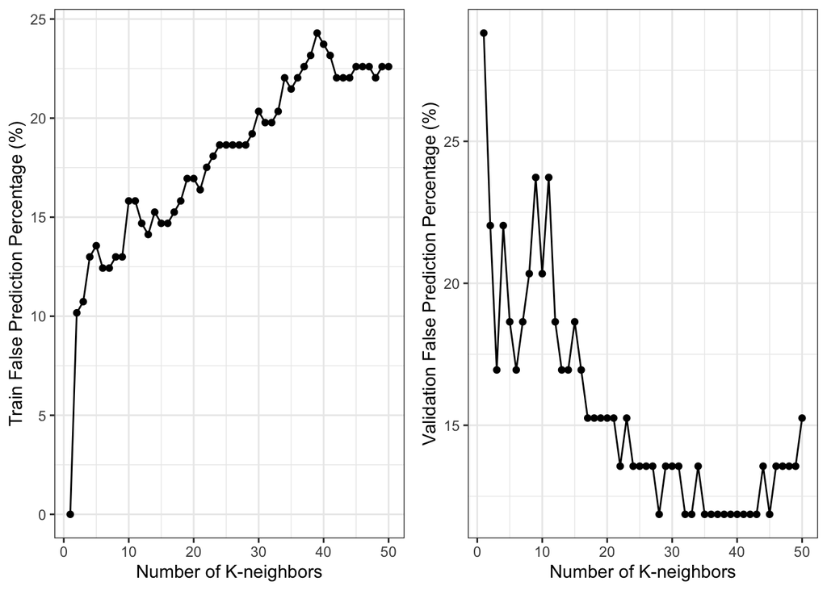

```r
  grid.arrange(trainDataFalsePredictionsPercentagePlot, validationDataFalsePredictionsPercentagePlot, ncol = 2) # display the plots
```

# Task 5.

Based on the previous plot, in order to report the performance of our model on the test data, we are going to use all the K-neighbors that returned the lowest false predictions percentage. We will retrain our model every time the number of K-neighbors is changing, with the train data now to be composed of the union of the train and the validation data. In the end, we will create a plot with all the different false prediction percentages that we are going to compute, selecting the lowest one as our optimal hyperparameter for our model.

```r
  trainAndValidationX <- rbind(trainX, validationX) # union of train and validation features
  trainAndValidationY <- c(trainY, validationY) # union of train and validation labels

  falsePredictionPercentagesWithOptimalKs <- data.frame(k = optimalKs) %>%
    mutate(falsePredictionsPercentage = map(k, ~computeFalsePredictionsPercentageKNN(trainAndValidationX, trainAndValidationY, testX, testY, .x))) # compute the false predictions percentages for every optimal K we found

  falsePredictionPercentagesWithOptimalKsPlot <- falsePredictionPercentagesWithOptimalKs %>% ggplot() + geom_col(aes(x = k, y = as.numeric(falsePredictionsPercentage), fill = k), width = 0.5, show.legend = FALSE) + # create gg plot and add a geom col
  scale_x_discrete(limits = as.vector(falsePredictionPercentagesWithOptimalKs[, 1])) + theme_bw() + labs(x = "Number of K-neighbors", y = "False Prediction Percentage (%)") # choose the number of K-neighbors to be shown on x axis, black and white background, set label names
```

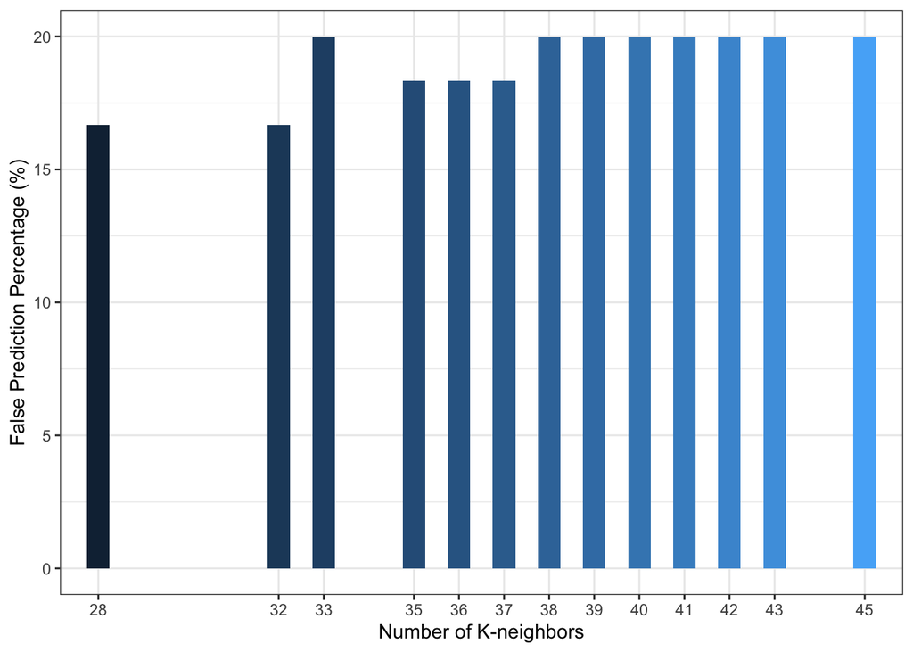

```r
  falsePredictionPercentagesWithOptimalKsPlot # display the plot
```

Looking at the graph above, we discover that the majority of the K-neighbors returned the same false prediction percentage (20%). The lowest percentage noted on test data equals 16.67%, which is obtained by using 28 and 32 number of K-neighbors. We will randomly choose the first one as our hyperparameter for our model, so our hyperparameter equals to K $=$ 28. This percentage is 4.81% higher than the validation of false predictions percentage. This is quite abnormal, as we supposed to have a smaller one because we use more data to train our model and as we observed in Task 3 when we increase the amount of data used, we tend to receive a smaller percentage of error. On our test data, we get approximately 10 false predictions, from a total of 60 observations.

Furthermore, we are going to use the cross-validation to check if we can get better results on our test data. In the cross-validation method, we split the dataset into train and validation data, and test data. Then, we split further the train and validation data into segments (folds). Each segment is being used as validation data and the rest as training data. We use this method for every single segment until all segments had the role of validation data once. Next, we compare the mean percentage of false predictions of every K-neighbor used, and then we get the number of K-neighbors which achieved the smaller percentage. Finally, we will use this number of K-neighbors to check our false prediction percentage on our test data. Theoretically, the percentage that we are going to compute, have to be lower than the one we computed before.

```r
  trainValidationByFold <- function(trainAndValidationData, fold, numberOfFolds) { # split train and validation data by fold

    numberOfTrainAndValidationData <- trainAndValidationData %>% nrow() # compute the number of train and validation data
    numberPerFold <- ceiling(numberOfTrainAndValidationData / numberOfFolds) # compute the observations per fold

    foldStart <- (fold - 1) * numberPerFold + 1 # first row number of fold
    foldEnd <- min(fold * numberPerFold, numberOfTrainAndValidationData) # last row number of fold
    foldIndicies <- seq(foldStart, foldEnd) # rows of observations

    validationData <- trainAndValidationData %>% filter(row_number() %in% foldIndicies) # take validation data

    trainData <- trainAndValidationData %>% filter(!row_number() %in% foldIndicies) # take train data (everything else)

    return(list(trainData = trainData, validationData = validationData)) # return the data

  }

  knnValidationFalsePredictionsPercentageByFoldK <- function(trainAndValidationData, fold, numberOfFolds, yName, k) { # compute validation false predictions percentage by fold

    dataSplit <- trainValidationByFold(trainAndValidationData, fold, numberOfFolds) # split data
    trainData <- dataSplit $ trainData # take the train data
    validationData <- dataSplit $ validationData # take the validation data

    tempFalsePredictionsPercentageOfValidation <- computeFalsePredictionsPercentageKNN(trainData %>% select(-yName), trainData %>% pull(yName), validationData %>% select(-yName), validationData %>% pull(yName), k) # compute the false prediction percentage of validation data

    return(tempFalsePredictionsPercentageOfValidation) # return the false prediction percentage of validation data

  }

  totalNumber <- data %>% nrow() # total number of observations
  testNumber <- ceiling(0.20 * totalNumber) # take 20% of our data as test data

  set.seed(11012021) # set seed for reproducibility
  data <- data %>% sample_n(size = nrow(.)) # randomly shuffle our data
  testIndicies <- seq(totalNumber - testNumber + 1, totalNumber) # take the last data

  testData <- data %>% filter(row_number() %in% testIndicies) # take data from the testIndicies
  trainAndValidationData <- data %>% filter(!row_number() %in% testIndicies) # take everything else

  numberOfFolds <- 10 # number of folds
  ks <- seq(1, 50, 1) # k neighbors

  crossValidationFalsePredictionsPercentage <- cross_df(list(k = ks, fold = seq(numberOfFolds))) %>% # create a data frame with all the ks used, number of folds, and the validation false prediction percentage per fold
    mutate(falsePredictionsPercentageOfValidation = map2_dbl(k, fold, ~knnValidationFalsePredictionsPercentageByFoldK(trainAndValidationData, .y, numberOfFolds, "target", .x))) %>% # compute the false prediction percentage of valdiation fold
    group_by(k) %>% # group by k-neighbors
    summarise(falsePredictionsPercentageOfValidation = mean(falsePredictionsPercentageOfValidation)) # take the mean of the false prediction percentages

  # find the hyper-parameter which minimizes the validation error
  minFalsePredictionsPercentageOfValidation <- crossValidationFalsePredictionsPercentage %>% pull(falsePredictionsPercentageOfValidation) %>% min() # take the minimum validation error

  optimalK <- crossValidationFalsePredictionsPercentage %>% filter(falsePredictionsPercentageOfValidation == minFalsePredictionsPercentageOfValidation) %>% pull(k) # take the optimal number of k neighbors
```

After using cross-validation, we figure out the minimum false predictions percentage to be 16.42% - a percentage a bit lower than the one we measured at the beginning of this Task -, using 20 K-neighbors. Next, we are going to use this hyperparameter on our test data and compute the error.

```r
  falsePredictionsErrorWithOptimalK <- computeFalsePredictionsPercentageKNN(trainAndValidationData %>% select(-"target"), trainAndValidationData %>% pull("target"), testData %>% select(-"target"), testData %>% pull("target"), optimalK) # with the optimal hyper-parameter using the combined train and validation data make predictions and compute the test error
```

We compute a false prediction error of 20%, which is higher than the 16.67% we found before. As we notice, our model keeps returning values that are not always following the theory, and, of course, the logic. The last thing that we are going to do with our dataset, is to do cross-validation to get a better understanding of performance on unseen data (it is also referred to sometimes as k * l - fold cross-validation). The difference with the cross-validation before is that now we are not going to separate our test data and make predictions on them. Contrarily, we are going to split our whole dataset into folds, and as we did before with the validation data, we are going to use each fold as test data once. The rest of the folds will play the role of train and validation data. Basically, this means that the whole dataset will be used both as test data as well as train and validation data. This is going to be computationally expensive, as we add another outer-loop through our dataset. The point of doing this is to measure the mean percentage of false predictions that we are going to have on unseen data. Once again, theoretically, we expect a percentage between 16.67% and 20%.

```r
  trainTestbyFold <- function(data, fold, numberOfFolds) { # split data into train and test by fold

    totalNumber <- data %>% nrow() # compute the total number of observations
    numberPerFold <- ceiling(totalNumber / numberOfFolds) # compute the number per fold

    foldStart <- (fold - 1) * numberPerFold + 1 # first row number of fold
    foldEnd <- min(fold * numberPerFold, totalNumber) # last row number of fold

    foldIndicies <- seq(foldStart, foldEnd) # compute the number of indicies

    foldTestData <- data %>% filter(row_number() %in% foldIndicies) # take the test data
    foldTrainAndValidationData <- data %>% filter(!row_number() %in% foldIndicies) # take the train and validation data

    return(list(trainAndValidationData = foldTrainAndValidationData, testData = foldTestData)) # return train, validation data and test data

  }

  getOptimalKByCV <- function(trainAndValidationData, numberOfFolds, yName, ks) { # compute the optimal k neighbor by using cross-validation

    folds <- seq(numberOfFolds) # number of folds

    crossValidationFalsePredictionsPercentageResults <- cross_df(list(k = ks, fold = folds)) %>% # create a data frame of all ks used, folds, and the false prediction percentage of validation
      mutate(falsePredictionsPercentageOfValidation = map2_dbl(k, fold, ~knnValidationFalsePredictionsPercentageByFoldK(trainAndValidationData, .y, numberOfFolds, yName, .x))) %>% # compute the false prediction percentage of validation
      group_by(k) %>% # group by k-neighbor
      summarize(falsePredictionsPercentageOfValidation = mean(falsePredictionsPercentageOfValidation)) # take the mean for each k

    minFalsePredictionsPercentageOfValidation <- crossValidationFalsePredictionsPercentageResults %>% pull(falsePredictionsPercentageOfValidation) %>% min() # take the min false prediction percentage
    optimalK <- crossValidationFalsePredictionsPercentageResults %>% filter(falsePredictionsPercentageOfValidation == minFalsePredictionsPercentageOfValidation) %>% pull(k) # find the optimal k used to get the min false prediction percentage

    return(optimalK) # return the optimal k

  }

  knnFalsePredictionsPercentageByFold <- function(data, fold, numberOfTestFolds, numberOfValidationFolds, yName, ks) { # compute the false prediction percentage by fold

    dataSplit <- trainTestbyFold(data, fold, numberOfTestFolds) # compute data split
    trainAndValidationData <- dataSplit $ trainAndValidationData # extract the train and validation data
    testData <- dataSplit $ testData # extract test data

    optimalK <- getOptimalKByCV(trainAndValidationData, numberOfValidationFolds, yName, ks) # compute optimal k

    optimisedKNNPercentage <- computeFalsePredictionsPercentageKNN(trainAndValidationData %>% select(-yName), trainAndValidationData %>% pull(yName), testData %>% select(-yName), testData %>% pull(yName), optimalK) # compute the false prediction percentage using the optimal k we found

    return(optimisedKNNPercentage) # return the percentage

  }


  knnFalsePredictionsPercentage <- function(data, numberOfTestFolds, numberOfValidationFolds, yName, ks) { # compute the false prediction percentage of the data

    set.seed(11012021) # set random seed for reproducibility
    data <- data %>% sample_n(nrow(.)) # shuffle data so we get random ones
    folds <- seq(numberOfTestFolds) # number of folds

    meanFalsePredictionsPercentage <- data.frame(fold = folds) %>% # compute the mean false prediction percentage
      mutate(falsePredictionsPercentage = map_dbl(fold, ~knnFalsePredictionsPercentageByFold(data, .x, numberOfTestFolds, numberOfValidationFolds, yName, ks))) %>% # compute the false prediction percentage of each fold
      pull(falsePredictionsPercentage) %>% # take the false prediction percentages
      mean() # compute the mean false prediction percentage

    return(meanFalsePredictionsPercentage) # return the mean false prediction percentage

  }

  knnfalsePredictionsPercentageOnUnseenData <- knnFalsePredictionsPercentage(data, numberOfTestFolds = 10, numberOfValidationFolds = 6, yName = "target", ks = seq(17)) # compute the mean false prediction percentage
```

We compute a false prediction percentage of 19.31% on unseen data, which is what we were expecting more or less. Basically, what this percentage actually means is that 19.31% of the time our model is going to return wrong predictions, although, this percentage will be lower as we add more observations to our dataset. This is not an anticipated percentage, but keeping in mind the complexity to figure out heart disease as well as the number of observations we had available (296), it still counts as a good result.

BIBLIOGRAPHY

https://en.wikipedia.org/wiki/Classification

https://en.wikipedia.org/wiki/K-nearest_neighbors_algorithm

https://www.ole.bris.ac.uk/bbcswebdav/pid-4980491-dt-content-rid-18204277_2/courses/EMATM0061_2020_TB-1/SlidesPDF/Lecture19NonLinearEstimation.pdf

https://www.ole.bris.ac.uk/bbcswebdav/pid-4980491-dt-content-rid-18296517_2/courses/EMATM0061_2020_TB-1/SlidesPDF/Lecture20Crossvalidation.pdf